# Pathway Prioritization Using a Bayesian MAGMA Model

Authors

Affiliations

Palle Duun Rohde

Genomic Medicine, Department of Health Science and Technology, Aalborg University, Denmark

Peter Sørensen

Center for Quantitative Genetics and Genomics, Aarhus University, Denmark

## Introduction

This tutorial introduces **Bayesian MAGMA** — a gene set prioritization approach utilizing **Bayesian Linear Regression (BLR)** models within the MAGMA gene set analysis framework.

The figure below shows a schematic overview of the workflow.  
In the initial step, **GWAS summary data** for the traits of interest are used to compute **gene-level Z-scores** using the **VEGAS (Versatile Gene-Based Association Study)** approach.

Next, a **design matrix** linking genes to gene sets is constructed to integrate curated pathway databases (e.g., KEGG).  
The Bayesian MAGMA model is then fitted using this design matrix as input predictors and the gene-level Z-scores as the response variable.  
This results in **posterior inclusion probabilities (PIPs)** for each gene set, representing the probability that the set is included in the model.

Gene sets with higher PIPs are prioritized, highlighting pathways most likely to explain genetic associations.  
The approach can also be extended to **multi-trait analyses**, enabling cross-trait exploration of pathway relevance.

See full details in *Gholipourshahraki T, et al. PLOS Genet. 20, e1011463 (2024)*.

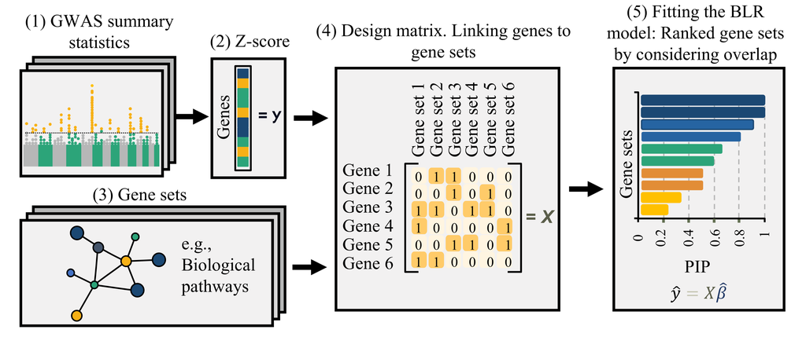

Figure 1. Schematic overview of the Bayesian MAGMA workflow.

## Simulation set up

This tutorial demonstrates how to simulate **gene-level association statistics** and **overlapping gene sets (pathways)** for enrichment analysis using MAGMA-style approaches, implemented either as OLS joint estimation or via Bayesian inference with BayesC or BayesR priors.

The tutorial includes the following key steps:

1. Simulate gene-level Z-scores with causal genes.
2. Create overlapping pathways with realistic size distributions.
3. Enrich specific pathways with causal genes.
4. Visualize pathway sizes and overlaps.
5. Perform gene set analysis using `magma()`-style models (linear and Bayesian).

## Step 0: Load libraries

```r
library(qgg)
library(ggplot2)
```

## Step 1: Basic Parameters

```r
set.seed(123)
n_genes <- 20000
n_assoc <-  100
n_pathways <- 100
effect_mean <- 2
effect_sd <- 1
```

## Step 2: Simulate Gene-Level Association Statistics

In this step, we simulate gene-level Z-scores for 20,000 genes,  
where a subset of 100 are truly associated (causal).  
We then visualize the results using a QQ plot that distinguishes  
causal genes (red) from null genes (grey).

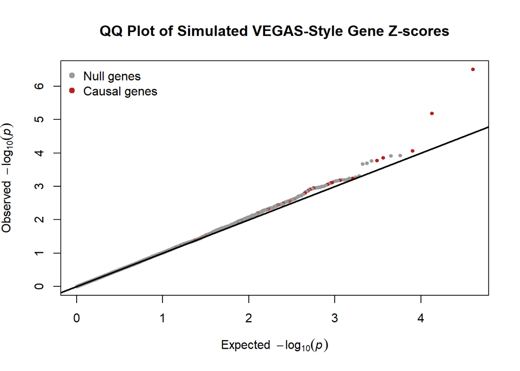

QQ plot of simulated gene-level associations showing causal (red) and null (grey) genes.

```r
genes <- paste0("Gene", seq_len(n_genes))

# --- Step 1: Null genes centered around 0 ---
z_scores <- rnorm(n_genes, mean = 0, sd = 1)
names(z_scores) <- genes

# --- Step 2: Define causal genes (stronger, possibly positive or negative) ---
associated_genes <- sample(genes, n_assoc)
z_scores[associated_genes] <- rnorm(n_assoc, mean = effect_mean, sd = effect_sd)

# --- Step 3: Compute two-tailed p-values (VEGAS-style) ---
p_values <- 2 * pnorm(-abs(z_scores))

# --- Step 4: QQ plot ---
df <- data.frame(
  Gene = genes,
  P = p_values,
  causal = genes %in% associated_genes
)
df <- df[order(df$P), ]
df$expected <- -log10(ppoints(n_genes))
df$observed <- -log10(df$P)

col_map <- c("FALSE" = "grey60", "TRUE" = "firebrick")

plot(df$expected, df$observed,
     pch = 19, cex = 0.6,
     col = col_map[as.character(df$causal)],
     xlab = expression(Expected~~-log[10](italic(p))),
     ylab = expression(Observed~~-log[10](italic(p))),
     main = "QQ Plot of Simulated VEGAS-Style Gene Z-scores")

abline(0, 1, col = "black", lwd = 2)
legend("topleft",
       legend = c("Null genes", "Causal genes"),
       col = c("grey60", "firebrick"), pch = 19, bty = "n")
```

## Step 3: Draw Realistic Gene Set Sizes

We use a **log-normal distribution** to simulate pathway sizes, resulting in a right-skewed distribution (many small pathways, few large ones).

```r
sizes_raw <- round(rlnorm(n_pathways, meanlog = log(80), sdlog = 0.6))
sizes <- pmin(pmax(sizes_raw, 15), 500)  # truncate to 15–500
summary(sizes)
```

```
   Min. 1st Qu.  Median    Mean 3rd Qu.    Max.
  15.00   53.75   75.00   92.77  119.25  259.00
```

## Step 4: Create Overlapping Pathways

Here, we simulate overlapping pathways. Each pathway shares some genes with previous ones, mimicking realistic biological redundancy.

```r
pathway_list <- vector("list", n_pathways)
names(pathway_list) <- paste0("Pathway_", seq_len(n_pathways))

for (i in seq_len(n_pathways)) {
  size <- sizes[i]

  if (i > 1 && runif(1) < 0.9) {  # 90% chance to overlap
    j <- sample(seq_len(i - 1), 1)  # pick existing pathway
    target_overlap <- round(size * runif(1, 0.20, 0.50))  # 20–50% overlap
    overlap_pool <- pathway_list[[j]]
    k <- min(target_overlap, length(overlap_pool), size)
    overlap_genes <- if (k > 0) sample(overlap_pool, k) else character(0)
    remaining_pool <- setdiff(genes, overlap_genes)
    n_remaining <- size - length(overlap_genes)
    new_genes <- if (n_remaining > 0) sample(remaining_pool, n_remaining) else character(0)
    pathway_list[[i]] <- unique(c(overlap_genes, new_genes))
  } else {
    pathway_list[[i]] <- sample(genes, size)
  }
}
```

## Step 5: Create Causal Pathways

We enrich 1–2 pathways with truly associated genes to simulate signal.

```r
n_enriched_paths <- 2
enriched_paths <- sample(names(pathway_list), n_enriched_paths)

for (p in enriched_paths) {
  n_enriched_genes <- 30
  enriched_genes <- sample(associated_genes, n_enriched_genes)
  pathway_list[[p]] <- unique(c(pathway_list[[p]], enriched_genes))
}

cat("Created", n_pathways, "pathways (15–500 genes each)\n")
```

```
Created 100 pathways (15–500 genes each)
```

```r
cat("Causal pathways:", paste(enriched_paths, collapse = ", "), "\n")
```

```
Causal pathways: Pathway_75, Pathway_53
```

## Step 6: Visualize Pathway Size Distribution

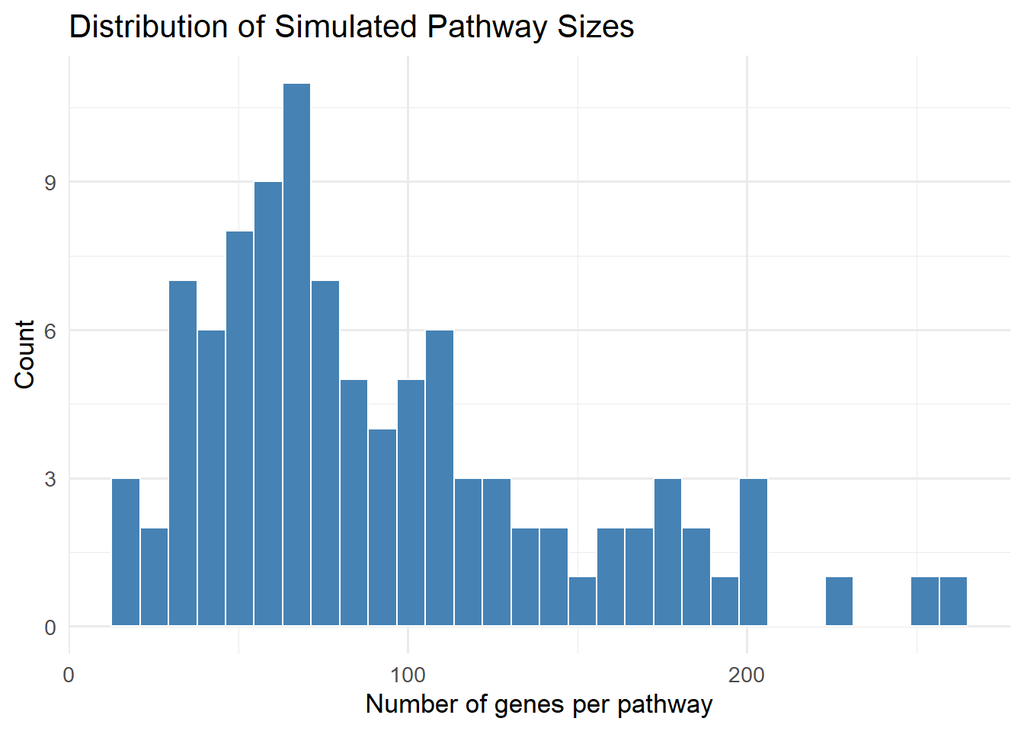

```r
sizes_df <- data.frame(Pathway = names(pathway_list), Size = sizes)

ggplot(sizes_df, aes(x = Size)) +
  geom_histogram(bins = 30, fill = "steelblue", color = "white") +
  theme_minimal(base_size = 13) +
  labs(
    title = "Distribution of Simulated Pathway Sizes",
    x = "Number of genes per pathway",
    y = "Count"
  )
```

## Step 7: Visualize Pathway Overlap

We calculate the **Jaccard index** (|A∩B| / |A∪B|) between pathways and visualize it with a heatmap.

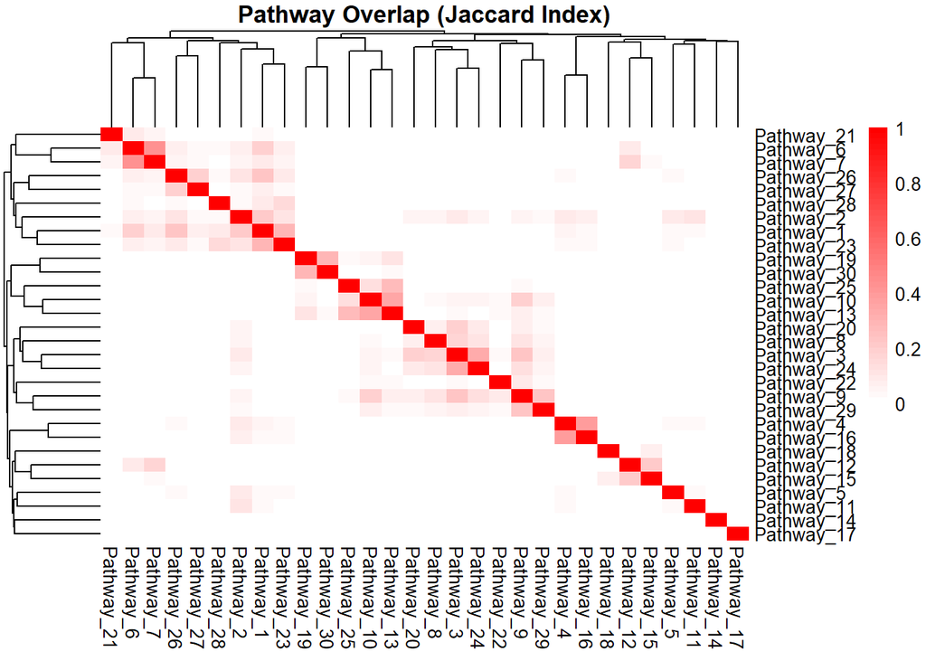

```r
n_show <- 30  # display subset
overlap_matrix <- matrix(NA, n_show, n_show,
                         dimnames = list(names(pathway_list)[1:n_show],
                                         names(pathway_list)[1:n_show]))

for (i in seq_len(n_show)) {
  for (j in seq_len(n_show)) {
    g1 <- pathway_list[[i]]
    g2 <- pathway_list[[j]]
    overlap_matrix[i, j] <- length(intersect(g1, g2)) / length(union(g1, g2))
  }
}

if (requireNamespace("pheatmap", quietly = TRUE)) {
  library(pheatmap)
  pheatmap(
    overlap_matrix,
    main = "Pathway Overlap (Jaccard Index)",
    color = colorRampPalette(c("white", "red"))(50),
    border_color = NA
  )
}
```

## Step 8: Run and Compare MAGMA-Style Gene Set Analyses

Here we compare three approaches implemented in `qgg::magma()`:

| Method | Model Type | Concept | Output |
| --- | --- | --- | --- |
| **Joint (fitM)** | Linear regression | Tests all pathways simultaneously | β-coefficients, SEs, *p*-values |
| **BayesC (fitC)** | Bayesian spike-and-slab | Selects relevant pathways by posterior inclusion probability (PIP) | Posterior means, PIPs |
| **BayesR (fitR)** | Bayesian mixture prior | Allows pathways to have small, moderate, or large effects | Posterior means, PIPs |

### Classical joint model (standard MAGMA-style regression)

```r
fitM <- magma(stat = z_scores, sets = pathway_list, type = "joint")
head(fitM)
```

```
           ID  m      b    seb      z            p
53 Pathway_53 45 0.0586 0.0072 8.1323 2.105592e-16
75 Pathway_75 76 0.0446 0.0076 5.8493 2.467936e-09
71 Pathway_71 63 0.0191 0.0083 2.2936 1.090724e-02
49 Pathway_49 61 0.0156 0.0082 1.9083 2.817681e-02
82 Pathway_82 85 0.0167 0.0091 1.8455 3.248288e-02
74 Pathway_74 54 0.0130 0.0072 1.7987 3.603322e-02
```

### Bayesian sparse model (BayesC)

```r
fitC <- magma(stat = z_scores, sets = pathway_list, method = "bayesC")
head(fitC)
```

```
           ID   m      b    PIP
53 Pathway_53  45 0.0586 1.0000
75 Pathway_75  76 0.0441 1.0000
28 Pathway_28  48 0.0000 0.0020
62 Pathway_62 109 0.0000 0.0018
71 Pathway_71  63 0.0000 0.0018
13 Pathway_13 119 0.0000 0.0016
```

### Bayesian mixture model (BayesR)

```r
fitR <- magma(stat = z_scores, sets = pathway_list, method = "bayesR")
head(fitR)
```

```
           ID   m       b    PIP
53 Pathway_53  45  0.0586 1.0000
75 Pathway_75  76  0.0440 1.0000
28 Pathway_28  48 -0.0005 0.0284
82 Pathway_82  85  0.0003 0.0166
13 Pathway_13 119 -0.0002 0.0146
63 Pathway_63 187 -0.0002 0.0130
```

### Summarize and Compare Outputs

```r
# Extract comparable metrics
results <- list(
  Joint = fitM[, c("ID", "b", "p")],
  BayesC = fitC[, c("ID", "b", "PIP")],
  BayesR = fitR[, c("ID", "b", "PIP")]
)

# Merge results by Pathway ID
merged_results <- Reduce(function(x, y) merge(x, y, by = "ID", all = TRUE), results)
colnames(merged_results) <- c("Pathway", "b_joint", "p_joint", "b_bayesC", "PIP_bayesC", "b_bayesR", "PIP_bayesR")
merged_results$is_enriched <- merged_results$Pathway %in% enriched_paths

head(merged_results[order(-merged_results$PIP_bayesC), ])
```

```
      Pathway b_joint      p_joint b_bayesC PIP_bayesC b_bayesR PIP_bayesR
50 Pathway_53  0.0586 2.105592e-16   0.0586     1.0000   0.0586     1.0000
74 Pathway_75  0.0446 2.467936e-09   0.0441     1.0000   0.0440     1.0000
22 Pathway_28 -0.0188 9.947193e-01   0.0000     0.0020  -0.0005     0.0284
60 Pathway_62  0.0134 3.969070e-02   0.0000     0.0018   0.0001     0.0120
70 Pathway_71  0.0191 1.090724e-02   0.0000     0.0018   0.0001     0.0068
6  Pathway_13 -0.0154 9.553190e-01   0.0000     0.0016  -0.0002     0.0146
   is_enriched
50        TRUE
74        TRUE
22       FALSE
60       FALSE
70       FALSE
6        FALSE
```

### Visualize Comparison of Evidence

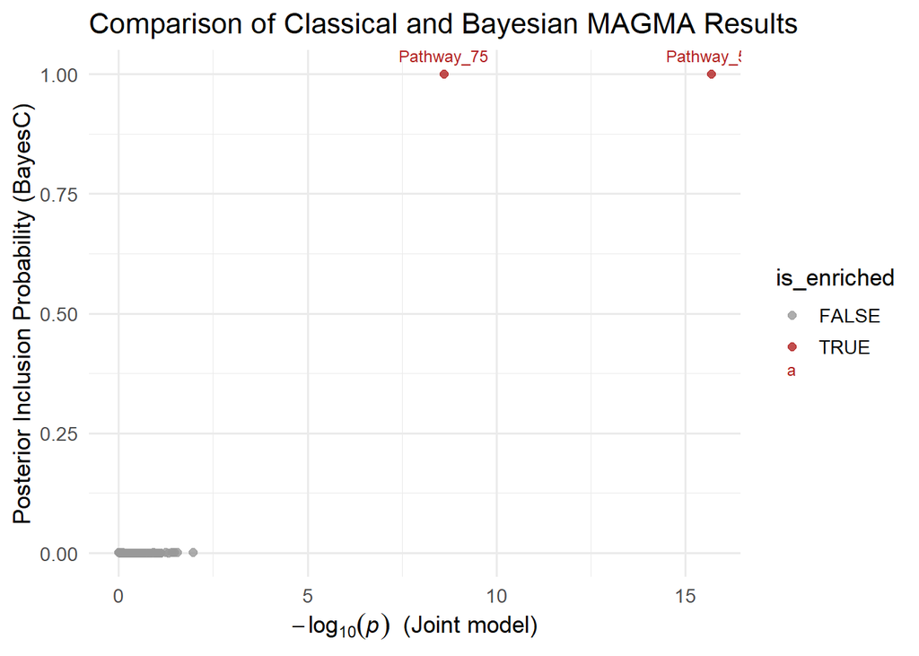

```r
library(ggplot2)

ggplot(merged_results, aes(x = -log10(p_joint), y = PIP_bayesC, color = is_enriched)) +
  geom_point(size = 2, alpha = 0.8) +
  geom_text(data = subset(merged_results, is_enriched), aes(label = Pathway),
            vjust = -1, size = 3.2) +
  scale_color_manual(values = c("FALSE" = "grey60", "TRUE" = "firebrick")) +
  labs(
    x = expression(-log[10](italic(p))~~"(Joint model)"),
    y = "Posterior Inclusion Probability (BayesC)",
    title = "Comparison of Classical and Bayesian MAGMA Results"
  ) +
  theme_minimal(base_size = 13)
```